# slides slides

## use dataset for loan

link dataset: https://s3.amazonaws.com/udacity-hosted-downloads/ud651/prosperLoanData.csv

## data pipline

- data exploration
- data cleaning
- data visualization
- uinvariate
- bivariate
- multivariate

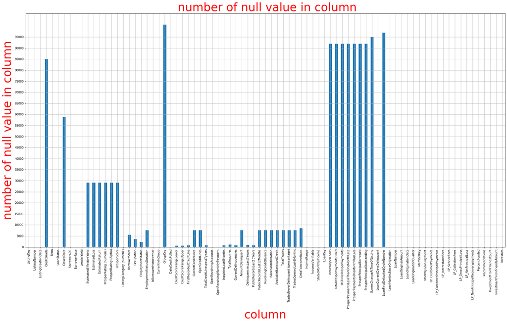

```python
plt.figure(figsize = (30,15))
null_val = df.isnull().sum()
null_val.plot(kind='bar')
plt.yticks([i for i in np.arange(0,100000,5000)])
plt.grid()
plt.xlabel('column' , color ='red', fontsize=40)
plt.ylabel('number of null value in column', color ='red', fontsize=40)
plt.title(" number of null value in column", color ='red', fontsize=40)
```

## summary after clean data

1- after exploration data i found that alot of nan value in row then i solved this problem using alot of statistics mode

- fill nan value with numeric data using mean
- fill nan value with categorical data using mode
- fill nan value in columns date with 0
- then drop the rest of the nan value in row

## visualize data

- univariate
- bivariate
- multivariate

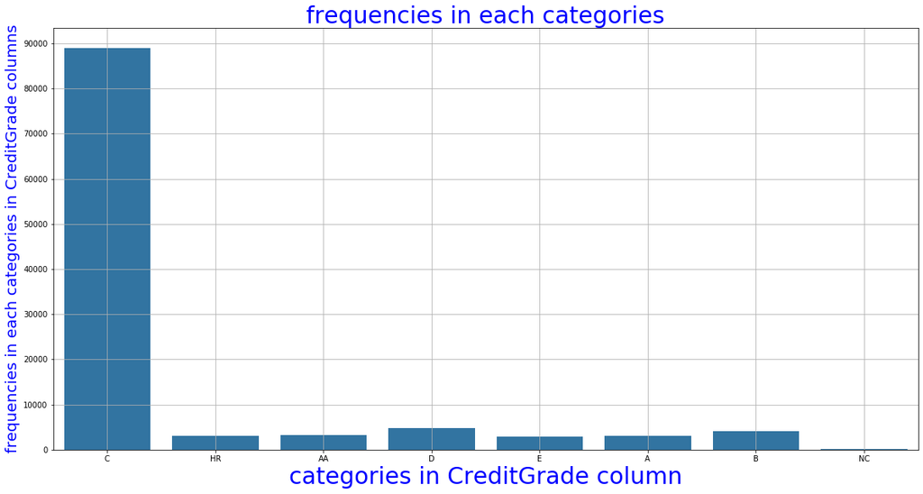

```python
plt.figure(figsize = (20,10))
base_color = sns.color_palette()[0]
sns.countplot(data = df , x = 'CreditGrade' , color = base_color)
plt.yticks([i for i in np.arange(0,100000, 10000)])
plt.grid()
plt.xlabel('categories in CreditGrade column' , fontsize = 30, color ='blue')
plt.ylabel('frequencies in each categories in CreditGrade columns' , fontsize = 20 , color = 'blue')
plt.title('frequencies in each categories', fontsize = 30 ,color = 'blue')
```

## this plot above give me insigt :

- high frequencies in categories is c
- the highest categories i used it to fill nan value with this mode

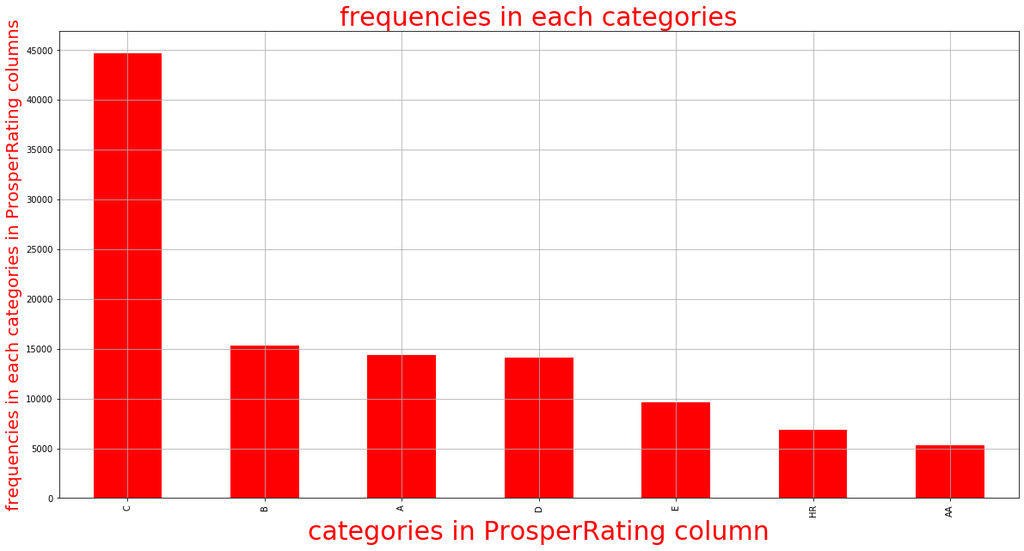

```python
plt.figure(figsize=(20,10))
plt.yticks([i for i in np.arange(0,50000, 5000)])
df['ProsperRating (Alpha)'].value_counts().plot(kind = 'bar' , color = 'red')
plt.grid()

plt.xlabel('categories in ProsperRating column' , fontsize = 30, color ='red')
plt.ylabel('frequencies in each categories in ProsperRating columns' , fontsize = 20 , color = 'red')
plt.title('frequencies in each categories', fontsize = 30 ,color = 'red')
```

## summary in above plot

###### what is the higest categories in ProsperRating column ??

- c is the higest

```
(-1.100166979465697, 1.100965035280418, -1.1010805595262319, 1.100051455219883)
```

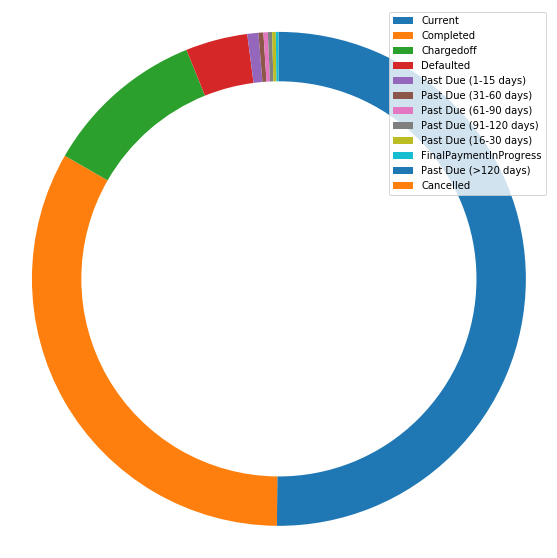

```python
plt.figure(figsize = (15,10))

sort_counts = df['LoanStatus'].value_counts()
plt.pie(sort_counts   , startangle = 90 ,counterclock = False, rotatelabels=True , wedgeprops = {'width' : 0.2}  )
plt.legend( labels =sort_counts.index , loc="best")
plt.axis('square')
```

## from above figure i notice that

- 50% from human is current to loan money
- 33% complete process is finished and take money

## hint:

i can't appear percentage of process because alot of categories in small area and i can't appear percentage

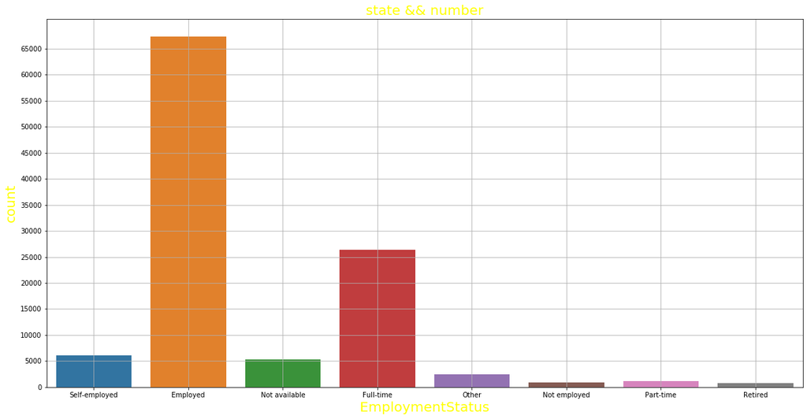

```python
base_color = sns.color_palette()[4]
plt.figure(figsize=(20,10))
plt.xlabel('state of people which take loan ' , color = 'yellow' , fontsize = 20)
plt.ylabel(" numner of people" , color = 'yellow' , fontsize = 20)
plt.title("state && number" , color = 'yellow' , fontsize =20)
plt.yticks([i for i in np.arange(0,70000 , 5000)])
sns.countplot(data = df , x = 'EmploymentStatus')
plt.grid()
```

## summary for above figure

- employed have the highest number which taken loan

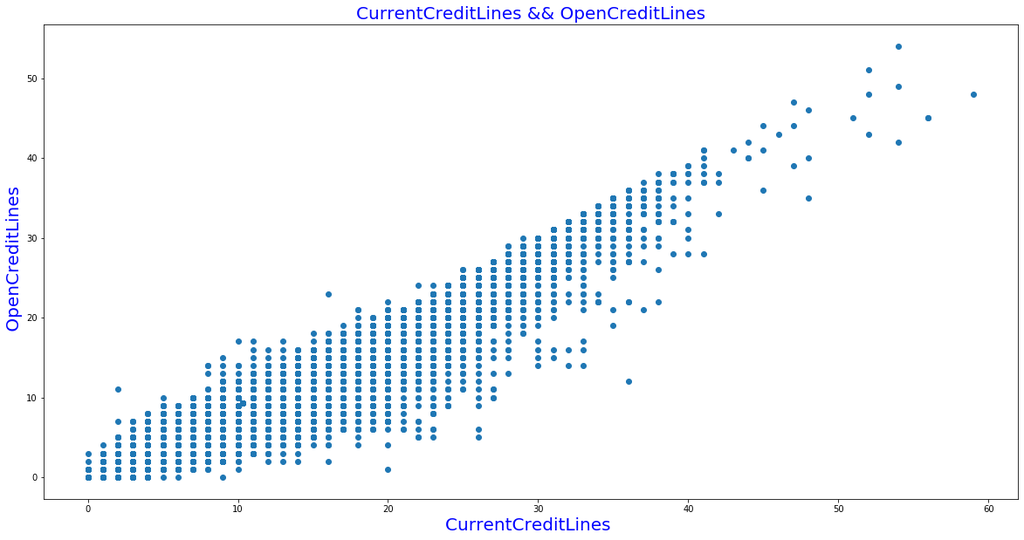

```python
plt.figure(figsize=(20,10))

plt.xlabel('CurrentCreditLines ' , color = 'blue' , fontsize = 20)
plt.ylabel(" OpenCreditLines" , color = 'blue' , fontsize = 20)

plt.title("CurrentCreditLines && OpenCreditLines" , color = 'blue' , fontsize =20)
plt.scatter(data = df , x = 'CurrentCreditLines' , y = 'OpenCreditLines')
```

## summary for above figure:

relation between column is linear relation and this is positive correlation

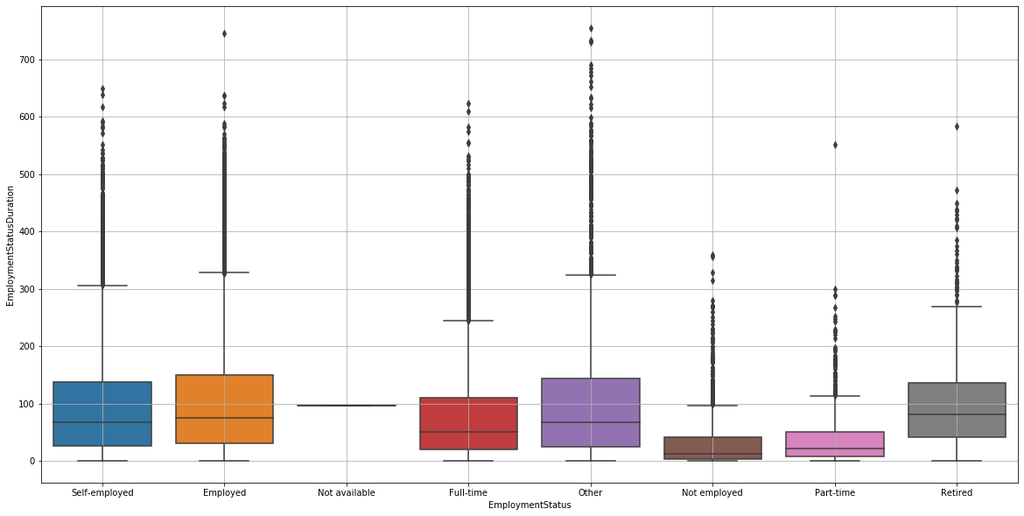

```python
base_color = sns.color_palette()[0]
plt.figure(figsize=(20,10))
sns.boxplot(data = df , x = 'EmploymentStatus' , y='EmploymentStatusDuration')
plt.grid()
```

## summary for above figure:

i want to draw boxplot between EmploymentStatusDuration && EmploymentStatus

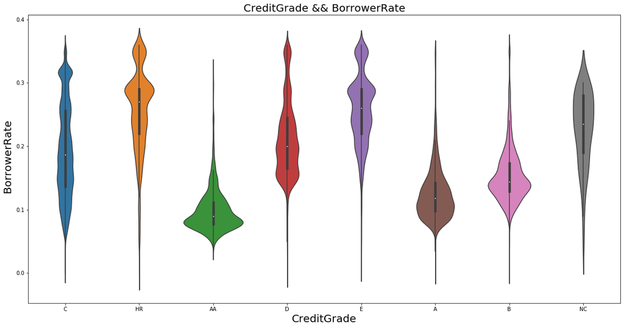

```python
base_color = sns.color_palette()[7]
plt.figure(figsize=(20,10))
sns.violinplot(data = df , x='CreditGrade', y='BorrowerRate' )
plt.xlabel('CreditGrade' , color = 'black' , fontsize = 20)
plt.ylabel(" BorrowerRate" , color = 'black' , fontsize = 20)
plt.title("CreditGrade && BorrowerRate" , color = 'black' , fontsize =20)
```

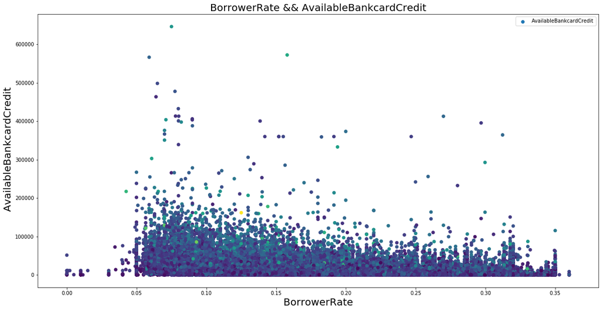

```python
plt.figure(figsize=(20,10))
plt.scatter(data = df , x='BorrowerRate' ,  y ='AvailableBankcardCredit' ,c = 'TotalTrades')
plt.xlabel('BorrowerRate' , color = 'black' , fontsize = 20)
plt.ylabel(" AvailableBankcardCredit" , color = 'black' , fontsize = 20)
plt.title("BorrowerRate && AvailableBankcardCredit" , color = 'black' , fontsize =20)
plt.legend()
```

[figure not shown]

```python
g = sns.FacetGrid(data = df , col = 'EmploymentStatus' , size = 10 )
g.map(plt.scatter , 'CreditScoreRangeLower' ,'OpenRevolvingAccounts')
plt.figure(figsize=(20,10))
g.add_legend()
```

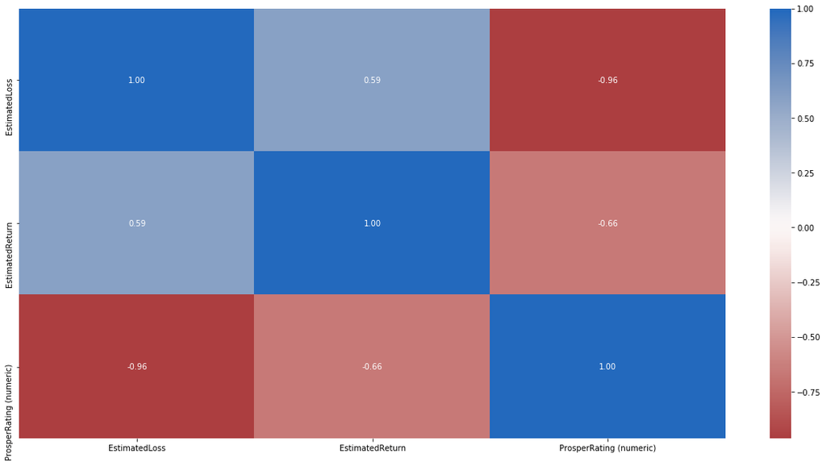

```python
plt.figure(figsize=(20,10))
df2 = df.iloc[: ,10:13]
sns.heatmap(df2.corr() , annot =True ,  fmt = '.2f',cmap = 'vlag_r', center = 0)
```

### summary for figure above :

- relation between the three column [EstimatedLoss , EstimatedReturn , ProsperRating (numeric)]
- high positive correlation between [EstimatedReturn ,EstimatedLoss ]
- high negative correlation is between [EstimatedLoss , ProsperRating (numeric)]

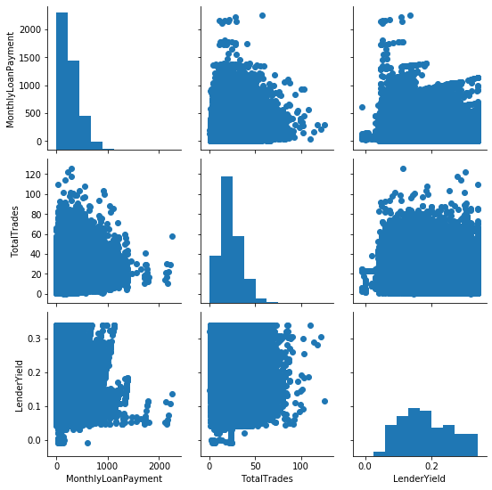

```python
plt.figure(figsize=(20,10))
g = sns.PairGrid(data = df, vars = ['MonthlyLoanPayment', 'TotalTrades','LenderYield'])
g.map_diag(plt.hist)
g.map_offdiag(plt.scatter)
```

## summary

this project pass with alot of step

- explore data set which have alot of null value in it
- after explore data i started to clean it:

1- fill nan value(numeric) with mean 2- fill nan value(categorical) with mode

- drop the rest of row which have nan value

# ask alot of question to explore data and understand relation between columns

- i put this question in readme file and graphs give me answer to this question
- using univariate to give me frequencies to all categories in column
- using bivariate to give me relation between two column
- using multivariate to give me relation between alot of column